# **Comparative Analysis of Eighteen Machine Learning Models for Stock Price Forecasting in the Financial Sector Using Historical Yahoo Finance Data.**

### **Transaction Type distribution across Symbol Types**

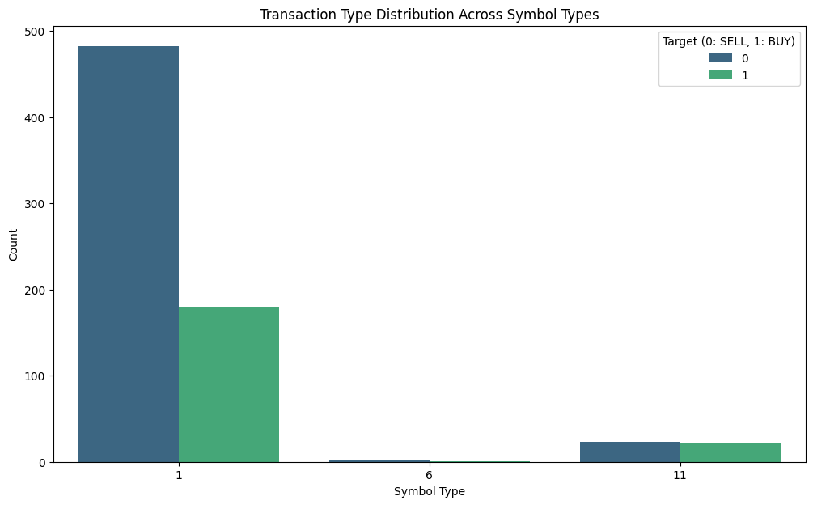

```python
plt.figure(figsize=(12, 7))
sns.countplot(x='symbolType', hue='Target', data=df_final, palette='viridis')
plt.title('Transaction Type Distribution Across Symbol Types')
plt.xlabel('Symbol Type')
plt.ylabel('Count')
plt.legend(title='Target (0: SELL, 1: BUY)')
plt.show()
```

### **Transaction Type distribution by Has Options**

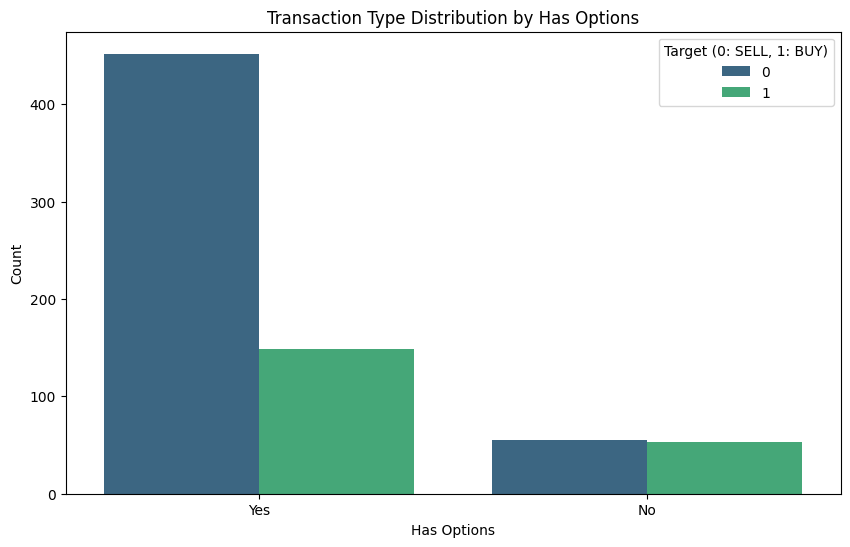

```python
import matplotlib.pyplot as plt
import seaborn as sns

plt.figure(figsize=(10, 6))
sns.countplot(x='hasOptions', hue='Target', data=df_final, palette='viridis')
plt.title('Transaction Type Distribution by Has Options')
plt.xlabel('Has Options')
plt.ylabel('Count')
plt.legend(title='Target (0: SELL, 1: BUY)')
plt.show()
```

### **Average Amount by Symbol Type**

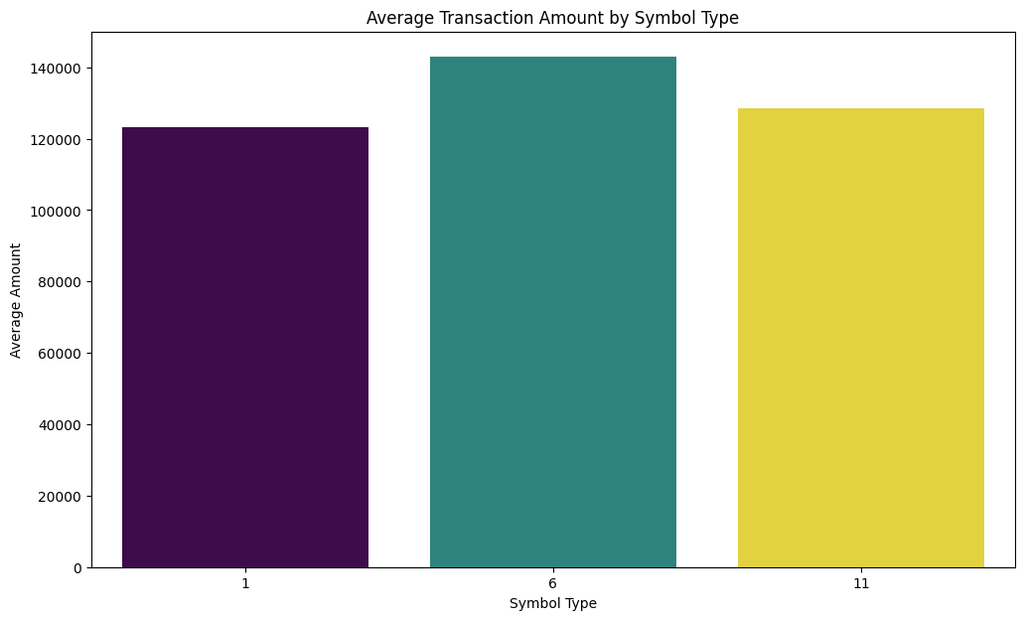

```python
# Calculate the average 'amount' for each 'symbolType'
average_amount_by_symbol_type = df_final.groupby('symbolType')['amount'].mean().reset_index()

# Create a bar plot
plt.figure(figsize=(12, 7))
sns.barplot(x='symbolType', y='amount', hue='symbolType', data=average_amount_by_symbol_type, palette='viridis', legend=False)
plt.title('Average Transaction Amount by Symbol Type')
plt.xlabel('Symbol Type')
plt.ylabel('Average Amount')
plt.show()
```

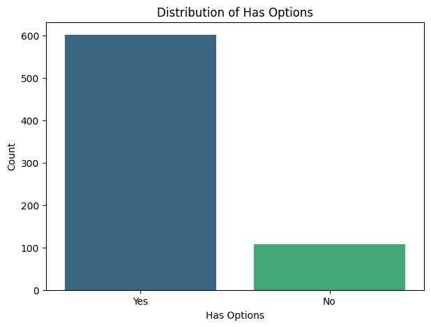

```python
plt.figure(figsize=(7, 5))
sns.countplot(x='hasOptions', data=df_final, palette='viridis', hue='hasOptions', legend=False)
plt.title('Distribution of Has Options')
plt.xlabel('Has Options')
plt.ylabel('Count')
plt.show()
```

### **Distribution of 'symbolCode'**

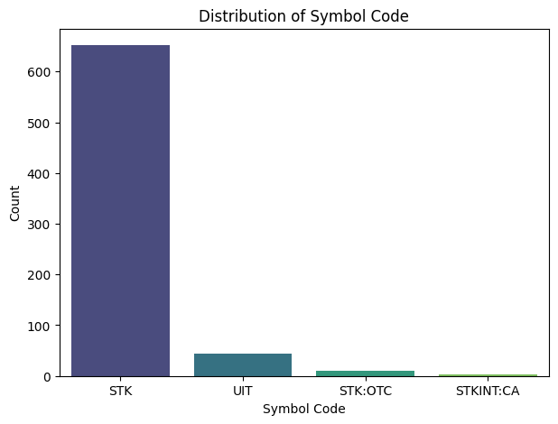

```python
plt.figure(figsize=(7, 5))
sns.countplot(x='symbolCode', data=df_final, palette='viridis', hue='symbolCode', legend=False)
plt.title('Distribution of Symbol Code')
plt.xlabel('Symbol Code')
plt.ylabel('Count')
plt.show()
```

### **Pair Plot of Numerical Features and Target**

```
### Pair Plot of Numerical Features and Target:
```

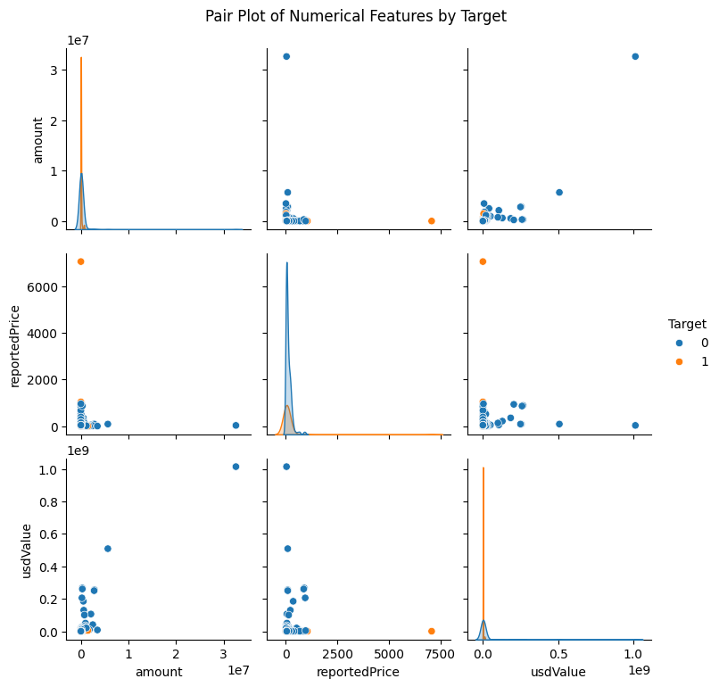

```python
print("\n### Pair Plot of Numerical Features and Target:\n")
sns.pairplot(df_final[numerical_features + ['Target']], hue='Target', diag_kind='kde')
plt.suptitle('Pair Plot of Numerical Features by Target', y=1.02)
plt.show()
```

# **Relationships Between Variables**

```python
display(df_final[numerical_features + ['Target']].corr())
```

|  | amount | reportedPrice | usdValue | Target |
| --- | --- | --- | --- | --- |
| amount | 1.000000 | -0.018707 | 0.872569 | -0.040034 |
| reportedPrice | -0.018707 | 1.000000 | 0.054712 | -0.042423 |
| usdValue | 0.872569 | 0.054712 | 1.000000 | -0.071806 |
| Target | -0.040034 | -0.042423 | -0.071806 | 1.000000 |

```
### Correlation Matrix:
```

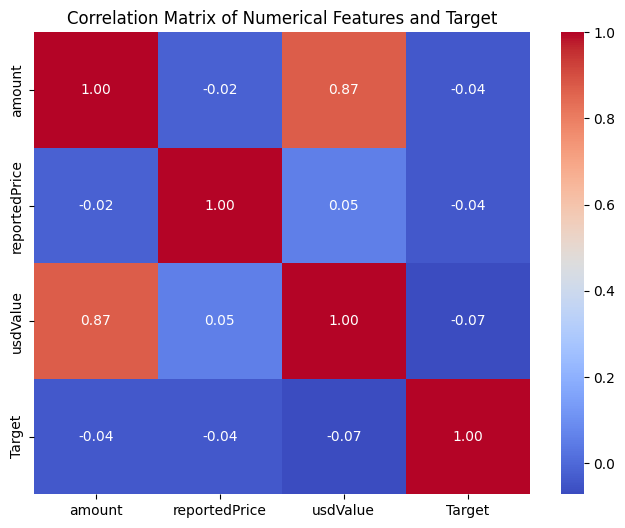

```python
print("\n### Correlation Matrix:\n")
plt.figure(figsize=(8, 6))
sns.heatmap(df_final[numerical_features + ['Target']].corr(), annot=True, cmap='coolwarm', fmt=".2f")
plt.title('Correlation Matrix of Numerical Features and Target')
plt.show()
```

# **Models**

### **Train-test split**

```python
x_train, x_test, y_train, y_test = train_test_split(
    X, y, test_size=0.25, shuffle=False
)

print("Data split into training and testing sets.")
print(f"x_train shape: {x_train.shape}")
print(f"x_test shape: {x_test.shape}")
print(f"y_train shape: {y_train.shape}")
print(f"y_test shape: {y_test.shape}")
```

```
Data split into training and testing sets.
x_train shape: (531, 3)
x_test shape: (178, 3)
y_train shape: (531,)
y_test shape: (178,)
```

### **Scaling**

```python
# Scaling
scaler = StandardScaler()
x_train = scaler.fit_transform(x_train)
x_test = scaler.transform(x_test)

print("Features scaled using StandardScaler.")
```

```
Features scaled using StandardScaler.
```

### **Handle imbalance (SMOTE) - only if there are at least two classes in y_train**

```python
# Handle imbalance (SMOTE) - only if there are at least two classes in y_train
if len(np.unique(y_train)) > 1:
    smote = SMOTE(random_state=42)
    x_train, y_train = smote.fit_resample(x_train, y_train)
    print("SMOTE applied to x_train and y_train for imbalance handling.")
    print(f"x_train shape after SMOTE: {x_train.shape}")
    print(f"y_train shape after SMOTE: {y_train.shape}")
    print("Target class distribution after SMOTE:")
    print(pd.Series(y_train).value_counts())
else:
    print("Warning: SMOTE not applied. y_train contains only one class. Binary classification might be problematic.")
```

```
SMOTE applied to x_train and y_train for imbalance handling.
x_train shape after SMOTE: (794, 3)
y_train shape after SMOTE: (794,)
Target class distribution after SMOTE:
Target
0    397
1    397
Name: count, dtype: int64
```

## **Model Accuracy**

```python
def calculate_accuracy_at_k(y_true, y_pred_proba, k_percentages):
    """
    Calculates Accuracy@k (precision at top k%) for given true labels and predicted probabilities.

    Args:
        y_true (array-like): The actual labels (0 or 1).
        y_pred_proba (array-like): The predicted probabilities for the positive class.
        k_percentages (list): A list of float values representing the top k% thresholds (e.g., [0.10, 0.20, 0.30]).

    Returns:
        dict: A dictionary where keys are 'Accuracy@k%' (e.g., 'Accuracy@10%') and values are the calculated precision percentages.
    """
    # 1. Combine y_true and y_pred_proba into a DataFrame
    df_combined = pd.DataFrame({'true_label': y_true, 'predicted_proba': y_pred_proba})

    # 2. Sort DataFrame by 'predicted_proba' in descending order
    df_combined = df_combined.sort_values(by='predicted_proba', ascending=False).reset_index(drop=True)

    # 3. Initialize dictionary to store results
    accuracy_at_k_results = {}

    # 4. Iterate through each k_percentage
    for k_percentage in k_percentages:
        # a. Calculate the number of samples for the current top k% threshold
        k_count = int(len(y_true) * k_percentage)

        # Handle the case where k_count is zero (e.g., k_percentage is very small or y_true is empty)
        if k_count == 0:
            accuracy_at_k_results[f'Accuracy@{int(k_percentage * 100)}%'] = 0.0
            continue

        # b. Select the top k_count samples from the sorted DataFrame
        top_k_df = df_combined.head(k_count)

        # c. Within these top k_count samples, count how many have a 'true_label' equal to 1
        correct_predictions = top_k_df['true_label'].sum()

        # d. Calculate the precision at k
        precision_at_k = (correct_predictions / k_count) * 100

        # e. Store this calculated precision (percentage) in the results dictionary
        accuracy_at_k_results[f'Accuracy@{int(k_percentage * 100)}%'] = precision_at_k

    return accuracy_at_k_results

print("The 'calculate_accuracy_at_k' function has been defined.")
```

```
The 'calculate_accuracy_at_k' function has been defined.
```

## **Linear & Probabilistic Models**

### **1. Linear Regression**

```
Accuracy score :  0.47191011235955055
Accuracy percent of Linear Regression :  47.2 %
Model score (on train data):  0.013245488793076743

Linear Regression Classification Report:
               precision    recall  f1-score   support

           0       0.90      0.16      0.28       110
           1       0.42      0.97      0.58        68

    accuracy                           0.47       178
   macro avg       0.66      0.57      0.43       178
weighted avg       0.72      0.47      0.39       178


Confusion Matrix:
 [[18 92]
 [ 2 66]]
TN=18, FP=92, FN=2, TP=66
```

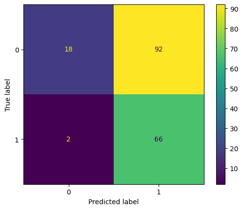

```
Linear Regression Accuracy@k: {'Accuracy@10%': np.float64(35.294117647058826), 'Accuracy@20%': np.float64(34.285714285714285), 'Accuracy@30%': np.float64(43.39622641509434)}
```

```python
# Train Linear Regression
# It treats y (0 or 1) as a continuous target
lr_model = LinearRegression()
lr_model.fit(x_train, y_train)

# Convert Continuous Output to Binary Class
# We use 0.5 as the default threshold, but in imbalanced data,
# you might lower this (e.g., 0.2) to increase Recall.
raw_predictions = lr_model.predict(x_test)
y_pred = (raw_predictions > 0.5).astype(int)

# Accuracy on test data
train_score_lr = metrics.accuracy_score(y_test, y_pred)
print('Accuracy score : ', train_score_lr)
print("Accuracy percent of Linear Regression : ", round(train_score_lr*100, 1), "%")
print("Model score (on train data): ", lr_model.score(x_train, y_train))

# Classification report and confusion matrix
print("\nLinear Regression Classification Report:\n", metrics.classification_report(y_test, y_pred))
cm = metrics.confusion_matrix(y_test, y_pred)
print("\nConfusion Matrix:\n", cm)

# TN, FP, FN, TP
TN, FP, FN, TP = cm.ravel()
print("TN={0}, FP={1}, FN={2}, TP={3}".format(TN, FP, FN, TP))

# Confusion matrix plot
disp = metrics.ConfusionMatrixDisplay(confusion_matrix=cm)
disp.plot()
plt.show()

# Calculate Accuracy@k
lr_accuracy_at_k = calculate_accuracy_at_k(y_test, raw_predictions, [0.10, 0.20, 0.30])
print("\nLinear Regression Accuracy@k:", lr_accuracy_at_k)
```

### **2. Logistic Regression (with SMOTE)**:

```
Accuracy score :  0.5337078651685393
Accuracy percent of Logistic Regression :  53.4 %
Model score (on resampled train data):  0.5906801007556675

Logistic Regression Classification Report:
               precision    recall  f1-score   support

           0       0.85      0.30      0.44       110
           1       0.45      0.91      0.60        68

    accuracy                           0.53       178
   macro avg       0.65      0.61      0.52       178
weighted avg       0.69      0.53      0.50       178


Confusion Matrix:
 [[33 77]
 [ 6 62]]
TN=33, FP=77, FN=6, TP=62
```

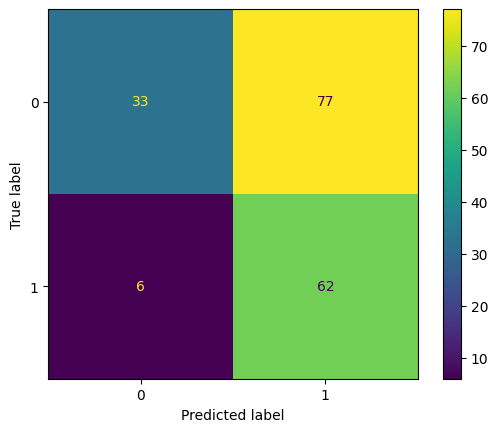

```
Logistic Regression Accuracy@k: {'Accuracy@10%': np.float64(64.70588235294117), 'Accuracy@20%': np.float64(57.14285714285714), 'Accuracy@30%': np.float64(64.15094339622641)}
```

```python
# Logic: Linear boundary with synthetic oversampling
# SMOTE is already applied globally in the data preparation step (Ggj7iUq-IX7Z) on x_train and y_train.
# So, directly use the resampled x_train, y_train for model training.
model = LogisticRegression(max_iter=1000, random_state=42).fit(x_train, y_train)

# Predict
y_pred = model.predict(x_test)
y_pred_proba = model.predict_proba(x_test)[:, 1] # Get probabilities for the positive class

# Accuracy on test data
train_score_lr = metrics.accuracy_score(y_test, y_pred)
print('Accuracy score : ', train_score_lr)
print("Accuracy percent of Logistic Regression : ", round(train_score_lr*100, 1), "%")
print("Model score (on resampled train data): ", model.score(x_train, y_train))

# Classification report and confusion matrix
print("\nLogistic Regression Classification Report:\n", metrics.classification_report(y_test, y_pred))
cm = metrics.confusion_matrix(y_test, y_pred)
print("\nConfusion Matrix:\n", cm)

# TN, FP, FN, TP
TN, FP, FN, TP = cm.ravel()
print("TN={0}, FP={1}, FN={2}, TP={3}".format(TN, FP, FN, TP))

# Confusion matrix plot
disp = metrics.ConfusionMatrixDisplay(confusion_matrix=cm)
disp.plot()
plt.show()

# Calculate Accuracy@k
logistic_accuracy_at_k = calculate_accuracy_at_k(y_test, y_pred_proba, [0.10, 0.20, 0.30])
print("\nLogistic Regression Accuracy@k:", logistic_accuracy_at_k)
```

### **3. Naïve Bayes**

```
Accuracy score :  0.43820224719101125
Accuracy percent of Naïve Bayes :  43.8 %
Model score (on train data):  0.5289672544080605

Naïve Bayes Classification Report:
               precision    recall  f1-score   support

           0       0.78      0.13      0.22       110
           1       0.40      0.94      0.56        68

    accuracy                           0.44       178
   macro avg       0.59      0.53      0.39       178
weighted avg       0.63      0.44      0.35       178


Confusion Matrix:
 [[14 96]
 [ 4 64]]
TN=14, FP=96, FN=4, TP=64
```

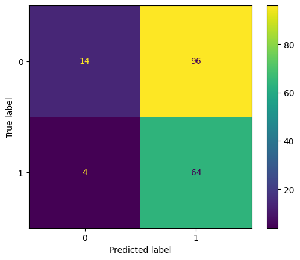

```
Naïve Bayes Accuracy@k: {'Accuracy@10%': np.float64(23.52941176470588), 'Accuracy@20%': np.float64(40.0), 'Accuracy@30%': np.float64(45.28301886792453)}
```

```python
# Logic: Assumes independence between features
model = GaussianNB().fit(x_train, y_train)

# Predict
y_pred = model.predict(x_test)
y_pred_proba = model.predict_proba(x_test)[:, 1] # Get probabilities for the positive class

# Accuracy on test data
train_score_nb = metrics.accuracy_score(y_test, y_pred)
print('Accuracy score : ', train_score_nb)
print("Accuracy percent of Naïve Bayes : ", round(train_score_nb*100, 1), "%")
print("Model score (on train data): ", model.score(x_train, y_train))

# Classification report and confusion matrix
print("\nNaïve Bayes Classification Report:\n", metrics.classification_report(y_test, y_pred))
cm = metrics.confusion_matrix(y_test, y_pred)
print("\nConfusion Matrix:\n", cm)

# TN, FP, FN, TP
TN, FP, FN, TP = cm.ravel()
print("TN={0}, FP={1}, FN={2}, TP={3}".format(TN, FP, FN, TP))

# Confusion matrix plot
disp = metrics.ConfusionMatrixDisplay(confusion_matrix=cm)
disp.plot()
plt.show()

# Calculate Accuracy@k
naive_bayes_accuracy_at_k = calculate_accuracy_at_k(y_test, y_pred_proba, [0.10, 0.20, 0.30])
print("\nNaïve Bayes Accuracy@k:", naive_bayes_accuracy_at_k)
```

### **4. LDA (Linear Discriminant Analysis)**

```
Accuracy score :  0.47191011235955055
Accuracy percent of LDA :  47.2 %
Model score (on train data):  0.5780856423173804

LDA Classification Report:
               precision    recall  f1-score   support

           0       0.90      0.16      0.28       110
           1       0.42      0.97      0.58        68

    accuracy                           0.47       178
   macro avg       0.66      0.57      0.43       178
weighted avg       0.72      0.47      0.39       178


Confusion Matrix:
 [[18 92]
 [ 2 66]]
TN=18, FP=92, FN=2, TP=66
```

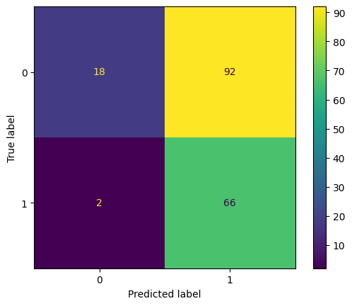

```
LDA Accuracy@k: {'Accuracy@10%': np.float64(35.294117647058826), 'Accuracy@20%': np.float64(34.285714285714285), 'Accuracy@30%': np.float64(43.39622641509434)}
```

```python
# Logic: Maximizes class separability
model = LinearDiscriminantAnalysis().fit(x_train, y_train)

# Predict
y_pred = model.predict(x_test)
y_pred_proba = model.predict_proba(x_test)[:, 1] # Get probabilities for the positive class

# Accuracy on test data
train_score_lda = metrics.accuracy_score(y_test, y_pred)
print('Accuracy score : ', train_score_lda)
print("Accuracy percent of LDA : ", round(train_score_lda*100, 1), "%")
print("Model score (on train data): ", model.score(x_train, y_train))

# Classification report and confusion matrix
print("\nLDA Classification Report:\n", metrics.classification_report(y_test, y_pred))
cm = metrics.confusion_matrix(y_test, y_pred)
print("\nConfusion Matrix:\n", cm)

# TN, FP, FN, TP
TN, FP, FN, TP = cm.ravel()
print("TN={0}, FP={1}, FN={2}, TP={3}".format(TN, FP, FN, TP))

# Confusion matrix plot
disp = metrics.ConfusionMatrixDisplay(confusion_matrix=cm)
disp.plot()
plt.show()

# Calculate Accuracy@k
lda_accuracy_at_k = calculate_accuracy_at_k(y_test, y_pred_proba, [0.10, 0.20, 0.30])
print("\nLDA Accuracy@k:", lda_accuracy_at_k)
```

### **5. Support Vector Machines (SVM)**

```
Accuracy score :  0.5786516853932584
Accuracy percent of SVM :  57.9 %
Model score (on resampled train data):  0.6473551637279596

SVM Classification Report:
               precision    recall  f1-score   support

           0       0.83      0.40      0.54       110
           1       0.47      0.87      0.61        68

    accuracy                           0.58       178
   macro avg       0.65      0.63      0.58       178
weighted avg       0.69      0.58      0.57       178


Confusion Matrix:
 [[44 66]
 [ 9 59]]
TN=44, FP=66, FN=9, TP=59
```

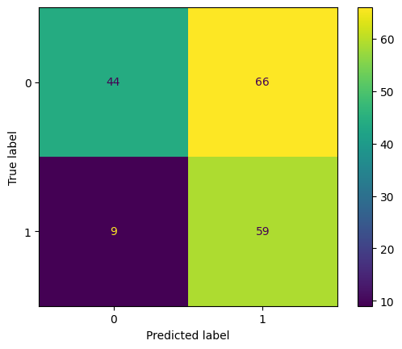

```
SVM Accuracy@k: {'Accuracy@10%': np.float64(47.05882352941176), 'Accuracy@20%': np.float64(51.42857142857142), 'Accuracy@30%': np.float64(49.056603773584904)}
```

```python
# Logic: Finds the hyperplane that maximizes the margin between classes
model = SVC(kernel='rbf', class_weight='balanced', probability=True, random_state=42)
model.fit(x_train, y_train)

# Predict
y_pred = model.predict(x_test)
y_pred_proba = model.predict_proba(x_test)[:, 1] # Get probabilities for the positive class

# Accuracy on test data
train_score_svm = metrics.accuracy_score(y_test, y_pred)
print('Accuracy score : ', train_score_svm)
print("Accuracy percent of SVM : ", round(train_score_svm*100, 1), "%")
print("Model score (on resampled train data): ", model.score(x_train, y_train))

# Classification report and confusion matrix
print("\nSVM Classification Report:\n", metrics.classification_report(y_test, y_pred))
cm = metrics.confusion_matrix(y_test, y_pred)
print("\nConfusion Matrix:\n", cm)

# TN, FP, FN, TP
TN, FP, FN, TP = cm.ravel()
print("TN={0}, FP={1}, FN={2}, TP={3}".format(TN, FP, FN, TP))

# Confusion matrix plot
disp = metrics.ConfusionMatrixDisplay(confusion_matrix=cm)
disp.plot()
plt.show()

# Calculate Accuracy@k
svm_accuracy_at_k = calculate_accuracy_at_k(y_test, y_pred_proba, [0.10, 0.20, 0.30])
print("\nSVM Accuracy@k:", svm_accuracy_at_k)
```

### **6. k-Nearest Neighbors (k-NN)**

```
Accuracy score :  0.6853932584269663
Accuracy percent of k-NN :  68.5 %
Model score (on resampled train data):  0.8779527559055118

k-NN Classification Report:
               precision    recall  f1-score   support

           0       0.79      0.67      0.73       110
           1       0.57      0.71      0.63        68

    accuracy                           0.69       178
   macro avg       0.68      0.69      0.68       178
weighted avg       0.70      0.69      0.69       178


Confusion Matrix:
 [[74 36]
 [20 48]]
TN=74, FP=36, FN=20, TP=48
```

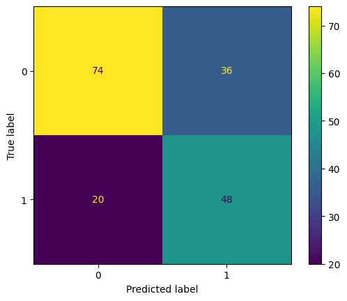

```
k-NN Accuracy@k: {'Accuracy@10%': np.float64(70.58823529411765), 'Accuracy@20%': np.float64(62.857142857142854), 'Accuracy@30%': np.float64(62.264150943396224)}
```

```python
# Logic: Classifies based on local density
# Apply TomekLinks for under-sampling (as per instruction for this cell)
X_res_tl, y_res_tl = TomekLinks().fit_resample(x_train, y_train)

# Initialize and fit k-NN model
model = KNeighborsClassifier(n_neighbors=5)
model.fit(X_res_tl, y_res_tl)

# Predict
y_pred = model.predict(x_test)
y_pred_proba = model.predict_proba(x_test)[:, 1] # Get probabilities for the positive class

# Accuracy on test data
train_score_knn = metrics.accuracy_score(y_test, y_pred)
print('Accuracy score : ', train_score_knn)
print("Accuracy percent of k-NN : ", round(train_score_knn*100, 1), "%")
print("Model score (on resampled train data): ", model.score(X_res_tl, y_res_tl))

# Classification report and confusion matrix
print("\nk-NN Classification Report:\n", metrics.classification_report(y_test, y_pred))
cm = metrics.confusion_matrix(y_test, y_pred)
print("\nConfusion Matrix:\n", cm)

# TN, FP, FN, TP
TN, FP, FN, TP = cm.ravel()
print("TN={0}, FP={1}, FN={2}, TP={3}".format(TN, FP, FN, TP))

# Confusion matrix plot
disp = metrics.ConfusionMatrixDisplay(confusion_matrix=cm)
disp.plot()
plt.show()

# Calculate Accuracy@k
knn_accuracy_at_k = calculate_accuracy_at_k(y_test, y_pred_proba, [0.10, 0.20, 0.30])
print("\nk-NN Accuracy@k:", knn_accuracy_at_k)
```

### **7. t-SNE (t-Distributed Stochastic Neighbor Embedding)**

A manifold learning technique for visualization and non-linear dimensionality reduction (similar to PCA, but better for identifying clusters in complex data)

```
Accuracy score :  0.601123595505618
Accuracy percent of t-SNE + LR :  60.1 %
Model score (on embedded train data):  0.6826196473551638

t-SNE + Logistic Regression Classification Report:
               precision    recall  f1-score   support

           0       0.83      0.45      0.58       110
           1       0.49      0.85      0.62        68

    accuracy                           0.60       178
   macro avg       0.66      0.65      0.60       178
weighted avg       0.70      0.60      0.60       178


Confusion Matrix:
 [[49 61]
 [10 58]]
TN=49, FP=61, FN=10, TP=58
```

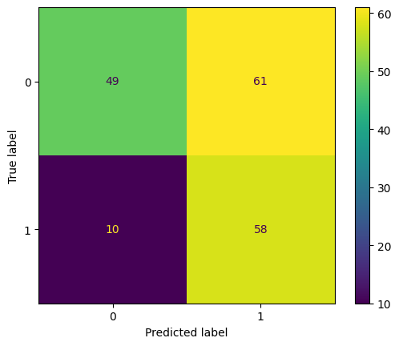

```
t-SNE + Logistic Regression Accuracy@k: {'Accuracy@10%': np.float64(76.47058823529412), 'Accuracy@20%': np.float64(62.857142857142854), 'Accuracy@30%': np.float64(52.83018867924528)}
```

```python
# Logic: Projects high-dimensional data into 2D or 3D while preserving local structure
# Note: sklearn's TSNE does not have a 'transform' method for new data.
# For demonstration purposes and to adhere to the template, we are applying
# fit_transform separately to train and test data. This means the embedded
# spaces are NOT guaranteed to be consistent, which is generally NOT ideal
# for robust model evaluation on unseen test data.

tsne = TSNE(n_components=2, perplexity=30, random_state=42)
X_train_embedded = tsne.fit_transform(x_train)

# For prediction on x_test, we re-run fit_transform on x_test.
# This creates an independent embedding for the test set.
# A more robust approach for production would involve learning a mapping
# from the original feature space to the embedded space.
tsne_test = TSNE(n_components=2, perplexity=30, random_state=42)
X_test_embedded = tsne_test.fit_transform(x_test)

# Train Logistic Regression on the 2D embedded training coordinates
model = LogisticRegression(random_state=42).fit(X_train_embedded, y_train)

# Predict on the 2D embedded test coordinates
y_pred = model.predict(X_test_embedded)
y_pred_proba = model.predict_proba(X_test_embedded)[:, 1] # Get probabilities for the positive class

# Accuracy on test data
train_score_tsne_lr = metrics.accuracy_score(y_test, y_pred)
print('Accuracy score : ', train_score_tsne_lr)
print("Accuracy percent of t-SNE + LR : ", round(train_score_tsne_lr*100, 1), "%")
print("Model score (on embedded train data): ", model.score(X_train_embedded, y_train))

# Classification report and confusion matrix
print("\nt-SNE + Logistic Regression Classification Report:\n", metrics.classification_report(y_test, y_pred))
cm = metrics.confusion_matrix(y_test, y_pred)
print("\nConfusion Matrix:\n", cm)

# TN, FP, FN, TP
TN, FP, FN, TP = cm.ravel()
print("TN={0}, FP={1}, FN={2}, TP={3}".format(TN, FP, FN, TP))

# Confusion matrix plot
disp = metrics.ConfusionMatrixDisplay(confusion_matrix=cm)
disp.plot()
plt.show()

# Calculate Accuracy@k
tsne_lr_accuracy_at_k = calculate_accuracy_at_k(y_test, y_pred_proba, [0.10, 0.20, 0.30])
print("\nt-SNE + Logistic Regression Accuracy@k:", tsne_lr_accuracy_at_k)
```

## **Tree-Based Ensembles**

### **8. Decision Trees (Cost-Sensitive)**

```
Accuracy score :  0.6741573033707865
Accuracy percent of Decision Tree :  67.4 %
Model score (on train data):  0.9987405541561712

Decision Tree Classification Report:
               precision    recall  f1-score   support

           0       0.75      0.70      0.73       110
           1       0.57      0.63      0.60        68

    accuracy                           0.67       178
   macro avg       0.66      0.67      0.66       178
weighted avg       0.68      0.67      0.68       178


Confusion Matrix:
 [[77 33]
 [25 43]]
TN=77, FP=33, FN=25, TP=43
```

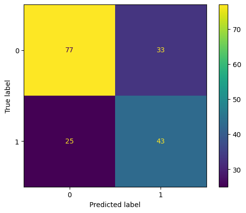

```
Decision Tree Accuracy@k: {'Accuracy@10%': np.float64(58.82352941176471), 'Accuracy@20%': np.float64(54.285714285714285), 'Accuracy@30%': np.float64(60.37735849056604)}
```

```python
# Logic: Non-linear splits focusing on minority class weight
model = DecisionTreeClassifier(class_weight='balanced', random_state=42).fit(x_train, y_train)

# Predict
y_pred = model.predict(x_test)
y_pred_proba = model.predict_proba(x_test)[:, 1] # Get probabilities for the positive class

# Accuracy on test data
train_score_dt = metrics.accuracy_score(y_test, y_pred)
print('Accuracy score : ', train_score_dt)
print("Accuracy percent of Decision Tree : ", round(train_score_dt*100, 1), "%")
print("Model score (on train data): ", model.score(x_train, y_train))

# Classification report and confusion matrix
print("\nDecision Tree Classification Report:\n", metrics.classification_report(y_test, y_pred))
cm = metrics.confusion_matrix(y_test, y_pred)
print("\nConfusion Matrix:\n", cm)

# TN, FP, FN, TP
TN, FP, FN, TP = cm.ravel()
print("TN={0}, FP={1}, FN={2}, TP={3}".format(TN, FP, FN, TP))

# Confusion matrix plot
disp = metrics.ConfusionMatrixDisplay(confusion_matrix=cm)
disp.plot()
plt.show()

# Calculate Accuracy@k
dt_accuracy_at_k = calculate_accuracy_at_k(y_test, y_pred_proba, [0.10, 0.20, 0.30])
print("\nDecision Tree Accuracy@k:", dt_accuracy_at_k)
```

### **9. Random Forest (Balanced)**

```
Accuracy score2 :  0.7134831460674157
Accuracy percent of RFC :  71.3 %
Model score:  0.9987405541561712
              precision    recall  f1-score   support

           0       0.80      0.72      0.76       110
           1       0.61      0.71      0.65        68

    accuracy                           0.71       178
   macro avg       0.70      0.71      0.70       178
weighted avg       0.73      0.71      0.72       178

Confusion Matrix:
 [[79 31]
 [20 48]]
TN=79, FP=31, FN=20, TP=48
```

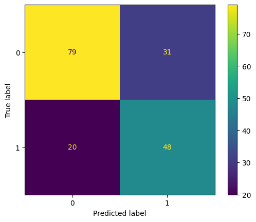

```
Balanced Random Forest Accuracy@k: {'Accuracy@10%': np.float64(70.58823529411765), 'Accuracy@20%': np.float64(65.71428571428571), 'Accuracy@30%': np.float64(67.9245283018868)}
```

```python
# Logic: Bagging with internal under-sampling
rand_model = BalancedRandomForestClassifier(n_estimators=100, random_state=42)
rand_model.fit(x_train, y_train)

# Predict
pred2 = rand_model.predict(x_test)
y_pred_proba = rand_model.predict_proba(x_test)[:, 1] # Get probabilities for the positive class

# Accuracy on test data
train_score_rand = metrics.accuracy_score(y_test, pred2)
print('Accuracy score2 : ', train_score_rand)
print("Accuracy percent of RFC : ", round(train_score_rand*100, 1), "%")
print("Model score: ", rand_model.score(x_train, y_train))

# Classification report and confusion matrix
print(metrics.classification_report(y_test, pred2))
cm = metrics.confusion_matrix(y_test, pred2)
print("Confusion Matrix:\n", cm)

# TN, FP, FN, TP
TN, FP, FN, TP = cm.ravel()
print("TN={0}, FP={1}, FN={2}, TP={3}".format(TN, FP, FN, TP))

# Confusion matrix plot
disp = metrics.ConfusionMatrixDisplay(confusion_matrix=cm)
disp.plot()
plt.show()

# Calculate Accuracy@k
rand_accuracy_at_k = calculate_accuracy_at_k(y_test, y_pred_proba, [0.10, 0.20, 0.30])
print("\nBalanced Random Forest Accuracy@k:", rand_accuracy_at_k)
```

### **10. Extra Trees (Extremely Randomized Trees)**

Similar to Random Forest, but it chooses split points completely at random for each feature, which can further reduce variance.

```
Accuracy score :  0.7247191011235955
Accuracy percent of Extra Trees :  72.5 %
Model score (on resampled train data):  0.9987405541561712

Extra Trees Classification Report:
               precision    recall  f1-score   support

           0       0.79      0.75      0.77       110
           1       0.63      0.68      0.65        68

    accuracy                           0.72       178
   macro avg       0.71      0.72      0.71       178
weighted avg       0.73      0.72      0.73       178


Confusion Matrix:
 [[83 27]
 [22 46]]
TN=83, FP=27, FN=22, TP=46
```

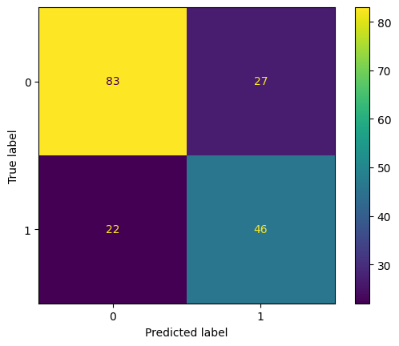

```
Extra Trees Accuracy@k: {'Accuracy@10%': np.float64(70.58823529411765), 'Accuracy@20%': np.float64(65.71428571428571), 'Accuracy@30%': np.float64(67.9245283018868)}
```

```python
# Logic: Randomized split points to reduce over-fitting on imbalanced noise
model = ExtraTreesClassifier(n_estimators=100, class_weight='balanced', random_state=42)
model.fit(x_train, y_train)

# Predict
y_pred = model.predict(x_test)
y_pred_proba = model.predict_proba(x_test)[:, 1] # Get probabilities for the positive class

# Accuracy on test data
train_score_et = metrics.accuracy_score(y_test, y_pred)
print('Accuracy score : ', train_score_et)
print("Accuracy percent of Extra Trees : ", round(train_score_et*100, 1), "%")
print("Model score (on resampled train data): ", model.score(x_train, y_train))

# Classification report and confusion matrix
print("\nExtra Trees Classification Report:\n", metrics.classification_report(y_test, y_pred))
cm = metrics.confusion_matrix(y_test, y_pred)
print("\nConfusion Matrix:\n", cm)

# TN, FP, FN, TP
TN, FP, FN, TP = cm.ravel()
print("TN={0}, FP={1}, FN={2}, TP={3}".format(TN, FP, FN, TP))

# Confusion matrix plot
disp = metrics.ConfusionMatrixDisplay(confusion_matrix=cm)
disp.plot()
plt.show()

# Calculate Accuracy@k
et_accuracy_at_k = calculate_accuracy_at_k(y_test, y_pred_proba, [0.10, 0.20, 0.30])
print("\nExtra Trees Accuracy@k:", et_accuracy_at_k)
```

### **11. AdaBoost (Adaptive Boosting)**

```
Accuracy score :  0.6741573033707865
Accuracy percent of AdaBoost :  67.4 %
Model score (on resampled train data):  0.7493702770780857

AdaBoost Classification Report:
               precision    recall  f1-score   support

           0       0.78      0.65      0.71       110
           1       0.56      0.71      0.62        68

    accuracy                           0.67       178
   macro avg       0.67      0.68      0.67       178
weighted avg       0.70      0.67      0.68       178


Confusion Matrix:
 [[72 38]
 [20 48]]
TN=72, FP=38, FN=20, TP=48
```

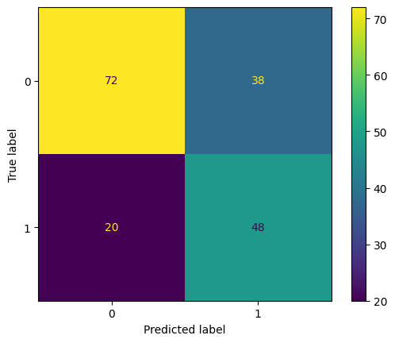

```
AdaBoost Accuracy@k: {'Accuracy@10%': np.float64(76.47058823529412), 'Accuracy@20%': np.float64(65.71428571428571), 'Accuracy@30%': np.float64(66.0377358490566)}
```

```python
# Logic: Weights misclassified instances more heavily
X_res_adasyn, y_res_adasyn = ADASYN(random_state=42).fit_resample(x_train, y_train)
model = AdaBoostClassifier(n_estimators=50, random_state=42).fit(X_res_adasyn, y_res_adasyn)

# Predict
y_pred = model.predict(x_test)
y_pred_proba = model.predict_proba(x_test)[:, 1] # Get probabilities for the positive class

# Accuracy on test data
train_score_ada = metrics.accuracy_score(y_test, y_pred)
print('Accuracy score : ', train_score_ada)
print("Accuracy percent of AdaBoost : ", round(train_score_ada*100, 1), "%")
print("Model score (on resampled train data): ", model.score(X_res_adasyn, y_res_adasyn))

# Classification report and confusion matrix
print("\nAdaBoost Classification Report:\n", metrics.classification_report(y_test, y_pred))
cm = metrics.confusion_matrix(y_test, y_pred)
print("\nConfusion Matrix:\n", cm)

# TN, FP, FN, TP
TN, FP, FN, TP = cm.ravel()
print("TN={0}, FP={1}, FN={2}, TP={3}".format(TN, FP, FN, TP))

# Confusion matrix plot
disp = metrics.ConfusionMatrixDisplay(confusion_matrix=cm)
disp.plot()
plt.show()

# Calculate Accuracy@k
ada_accuracy_at_k = calculate_accuracy_at_k(y_test, y_pred_proba, [0.10, 0.20, 0.30])
print("\nAdaBoost Accuracy@k:", ada_accuracy_at_k)
```

### **12. Gradient Boosting (HistGradientBoosting)**

Modern gradient boosting that handles missing values and large data well.

```
Accuracy score :  0.7078651685393258
Accuracy percent of Gradient Boosting :  70.8 %
Model score (on train data):  0.9785894206549118

Gradient Boosting Classification Report:
               precision    recall  f1-score   support

           0       0.78      0.73      0.75       110
           1       0.61      0.68      0.64        68

    accuracy                           0.71       178
   macro avg       0.69      0.70      0.70       178
weighted avg       0.72      0.71      0.71       178


Confusion Matrix:
 [[80 30]
 [22 46]]
TN=80, FP=30, FN=22, TP=46
```

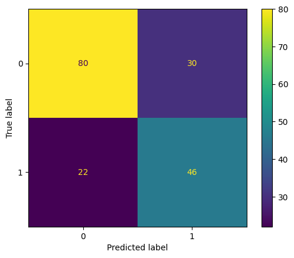

```
Gradient Boosting Accuracy@k: {'Accuracy@10%': np.float64(58.82352941176471), 'Accuracy@20%': np.float64(62.857142857142854), 'Accuracy@30%': np.float64(64.15094339622641)}
```

```python
# Logic: Sequential boosting focusing on previous errors
model = HistGradientBoostingClassifier(random_state=42)
model.fit(x_train, y_train)

# Predict
y_pred = model.predict(x_test)
y_pred_proba = model.predict_proba(x_test)[:, 1] # Get probabilities for the positive class

# Accuracy on test data
train_score_gb = metrics.accuracy_score(y_test, y_pred)
print('Accuracy score : ', train_score_gb)
print("Accuracy percent of Gradient Boosting : ", round(train_score_gb*100, 1), "%")
print("Model score (on train data): ", model.score(x_train, y_train))

# Classification report and confusion matrix
print("\nGradient Boosting Classification Report:\n", metrics.classification_report(y_test, y_pred))
cm = metrics.confusion_matrix(y_test, y_pred)
print("\nConfusion Matrix:\n", cm)

# TN, FP, FN, TP
TN, FP, FN, TP = cm.ravel()
print("TN={0}, FP={1}, FN={2}, TP={3}".format(TN, FP, FN, TP))

# Confusion matrix plot
disp = metrics.ConfusionMatrixDisplay(confusion_matrix=cm)
disp.plot()
plt.show()

# Calculate Accuracy@k
gb_accuracy_at_k = calculate_accuracy_at_k(y_test, y_pred_proba, [0.10, 0.20, 0.30])
print("\nGradient Boosting Accuracy@k:", gb_accuracy_at_k)
```

### **13. XGBoost (Extreme Gradient Boosting)**

Highly optimized distributed gradient boosting library.

```
Accuracy score :  0.7134831460674157
Accuracy percent of XGBoost :  71.3 %
Model score (on train data):  0.9911838790931989

XGBoost Classification Report:
               precision    recall  f1-score   support

           0       0.78      0.75      0.76       110
           1       0.62      0.66      0.64        68

    accuracy                           0.71       178
   macro avg       0.70      0.70      0.70       178
weighted avg       0.72      0.71      0.72       178


Confusion Matrix:
 [[82 28]
 [23 45]]
TN=82, FP=28, FN=23, TP=45
```

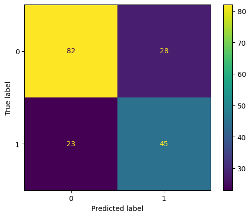

```
XGBoost Accuracy@k: {'Accuracy@10%': np.float64(70.58823529411765), 'Accuracy@20%': np.float64(71.42857142857143), 'Accuracy@30%': np.float64(64.15094339622641)}
```

```python
# Logic: Optimized Gradient Boosting with scale_pos_weight for imbalance
# Calculate scale_pos_weight based on the current y_train distribution
neg_count = np.sum(y_train == 0)
pos_count = np.sum(y_train == 1)
scale_pos_weight_value = neg_count / pos_count if pos_count > 0 else 1

model = XGBClassifier(scale_pos_weight=scale_pos_weight_value, random_state=42)
model.fit(x_train, y_train)

# Predict
y_pred = model.predict(x_test)
y_pred_proba = model.predict_proba(x_test)[:, 1] # Get probabilities for the positive class

# Accuracy on test data
train_score_xgb = metrics.accuracy_score(y_test, y_pred)
print('Accuracy score : ', train_score_xgb)
print("Accuracy percent of XGBoost : ", round(train_score_xgb*100, 1), "%")
print("Model score (on train data): ", model.score(x_train, y_train))

# Classification report and confusion matrix
print("\nXGBoost Classification Report:\n", metrics.classification_report(y_test, y_pred))
cm = metrics.confusion_matrix(y_test, y_pred)
print("\nConfusion Matrix:\n", cm)

# TN, FP, FN, TP
TN, FP, FN, TP = cm.ravel()
print("TN={0}, FP={1}, FN={2}, TP={3}".format(TN, FP, FN, TP))

# Confusion matrix plot
disp = metrics.ConfusionMatrixDisplay(confusion_matrix=cm)
disp.plot()
plt.show()

# Calculate Accuracy@k
xgb_accuracy_at_k = calculate_accuracy_at_k(y_test, y_pred_proba, [0.10, 0.20, 0.30])
print("\nXGBoost Accuracy@k:", xgb_accuracy_at_k)
```

### **14. LightGBM (Light Gradient Boosting Machine)**

A highly efficient framework that uses leaf-wise tree growth rather than level-wise growth, making it faster than standard XGBoost.

```
[LightGBM] [Info] Number of positive: 397, number of negative: 397
[LightGBM] [Info] Auto-choosing col-wise multi-threading, the overhead of testing was 0.000191 seconds.
You can set `force_col_wise=true` to remove the overhead.
[LightGBM] [Info] Total Bins 765
[LightGBM] [Info] Number of data points in the train set: 794, number of used features: 3
[LightGBM] [Info] [binary:BoostFromScore]: pavg=0.500000 -> initscore=0.000000
[LightGBM] [Warning] No further splits with positive gain, best gain: -inf
[LightGBM] [Warning] No further splits with positive gain, best gain: -inf
[LightGBM] [Warning] No further splits with positive gain, best gain: -inf
[LightGBM] [Warning] No further splits with positive gain, best gain: -inf
[LightGBM] [Warning] No further splits with positive gain, best gain: -inf
Accuracy score :  0.6966292134831461
Accuracy percent of LightGBM :  69.7 %
Model score (on train data):  0.9848866498740554

LightGBM Classification Report:
               precision    recall  f1-score   support

           0       0.76      0.74      0.75       110
           1       0.60      0.63      0.61        68

    accuracy                           0.70       178
   macro avg       0.68      0.68      0.68       178
weighted avg       0.70      0.70      0.70       178


Confusion Matrix:
 [[81 29]
 [25 43]]
TN=81, FP=29, FN=25, TP=43
```

[output not shown]

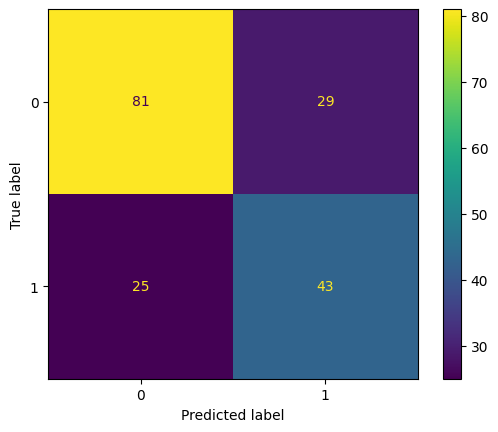

```
LightGBM Accuracy@k: {'Accuracy@10%': np.float64(58.82352941176471), 'Accuracy@20%': np.float64(65.71428571428571), 'Accuracy@30%': np.float64(66.0377358490566)}
```

```python
# Logic: Leaf-wise growth and Gradient-based One-Side Sampling (GOSS)
model = LGBMClassifier(is_unbalance=True, random_state=42)
model.fit(x_train, y_train)

# Predict
y_pred = model.predict(x_test)
y_pred_proba = model.predict_proba(x_test)[:, 1] # Get probabilities for the positive class

# Accuracy on test data
train_score_lgbm = metrics.accuracy_score(y_test, y_pred)
print('Accuracy score : ', train_score_lgbm)
print("Accuracy percent of LightGBM : ", round(train_score_lgbm*100, 1), "%")
print("Model score (on train data): ", model.score(x_train, y_train))

# Classification report and confusion matrix
print("\nLightGBM Classification Report:\n", metrics.classification_report(y_test, y_pred))
cm = metrics.confusion_matrix(y_test, y_pred)
print("\nConfusion Matrix:\n", cm)

# TN, FP, FN, TP
TN, FP, FN, TP = cm.ravel()
print("TN={0}, FP={1}, FN={2}, TP={3}".format(TN, FP, FN, TP))

# Confusion matrix plot
disp = metrics.ConfusionMatrixDisplay(confusion_matrix=cm)
disp.plot()
plt.show()

# Calculate Accuracy@k
lgbm_accuracy_at_k = calculate_accuracy_at_k(y_test, y_pred_proba, [0.10, 0.20, 0.30])
print("\nLightGBM Accuracy@k:", lgbm_accuracy_at_k)
```

### **15. CatBoost (Categorical Boosting)**

Developed by Yandex, this algorithm handles categorical features automatically and uses a "symmetric tree" structure to prevent prediction shift.

```
Accuracy score :  0.6966292134831461
Accuracy percent of CatBoost :  69.7 %
Model score (on train data):  0.9080604534005038

CatBoost Classification Report:
               precision    recall  f1-score   support

           0       0.78      0.71      0.74       110
           1       0.59      0.68      0.63        68

    accuracy                           0.70       178
   macro avg       0.68      0.69      0.69       178
weighted avg       0.71      0.70      0.70       178


Confusion Matrix:
 [[78 32]
 [22 46]]
TN=78, FP=32, FN=22, TP=46
```

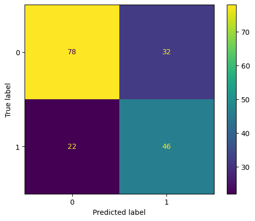

```
CatBoost Accuracy@k: {'Accuracy@10%': np.float64(70.58823529411765), 'Accuracy@20%': np.float64(65.71428571428571), 'Accuracy@30%': np.float64(67.9245283018868)}
```

```python
# Logic: Ordered boosting to solve the gradient bias problem
model = CatBoostClassifier(auto_class_weights='Balanced', verbose=0, random_state=42)
model.fit(x_train, y_train)

# Predict
y_pred = model.predict(x_test)
y_pred_proba = model.predict_proba(x_test)[:, 1] # Get probabilities for the positive class

# Accuracy on test data
train_score_cat = metrics.accuracy_score(y_test, y_pred)
print('Accuracy score : ', train_score_cat)
print("Accuracy percent of CatBoost : ", round(train_score_cat*100, 1), "%")
print("Model score (on train data): ", model.score(x_train, y_train))

# Classification report and confusion matrix
print("\nCatBoost Classification Report:\n", metrics.classification_report(y_test, y_pred))
cm = metrics.confusion_matrix(y_test, y_pred)
print("\nConfusion Matrix:\n", cm)

# TN, FP, FN, TP
TN, FP, FN, TP = cm.ravel()
print("TN={0}, FP={1}, FN={2}, TP={3}".format(TN, FP, FN, TP))

# Confusion matrix plot
disp = metrics.ConfusionMatrixDisplay(confusion_matrix=cm)
disp.plot()
plt.show()

# Calculate Accuracy@k
cat_accuracy_at_k = calculate_accuracy_at_k(y_test, y_pred_proba, [0.10, 0.20, 0.30])
print("\nCatBoost Accuracy@k:", cat_accuracy_at_k)
```

## **Neural Networks & Deep Learning**

### **16. Artificial Neural Networks (ANN - MLP)**

Multi-layer Perceptron

```
Accuracy score :  0.6685393258426966
Accuracy percent of ANN (MLP) :  66.9 %
Model score (on train data):  0.7040302267002518

ANN (MLP) Classification Report:
               precision    recall  f1-score   support

           0       0.81      0.60      0.69       110
           1       0.55      0.78      0.64        68

    accuracy                           0.67       178
   macro avg       0.68      0.69      0.67       178
weighted avg       0.71      0.67      0.67       178


Confusion Matrix:
 [[66 44]
 [15 53]]
TN=66, FP=44, FN=15, TP=53
```

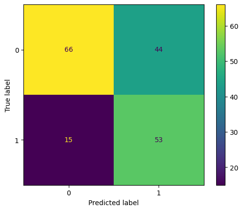

```
ANN (MLP) Accuracy@k: {'Accuracy@10%': np.float64(70.58823529411765), 'Accuracy@20%': np.float64(62.857142857142854), 'Accuracy@30%': np.float64(64.15094339622641)}
```

```python
# Logic: Layered neurons with non-linear activation functions
model = MLPClassifier(hidden_layer_sizes=(64, 32), max_iter=500, random_state=42)
model.fit(x_train, y_train)

# Predict
y_pred = model.predict(x_test)
y_pred_proba = model.predict_proba(x_test)[:, 1] # Get probabilities for the positive class

# Accuracy on test data
train_score_ann = metrics.accuracy_score(y_test, y_pred)
print('Accuracy score : ', train_score_ann)
print("Accuracy percent of ANN (MLP) : ", round(train_score_ann*100, 1), "%")
print("Model score (on train data): ", model.score(x_train, y_train))

# Classification report and confusion matrix
print("\nANN (MLP) Classification Report:\n", metrics.classification_report(y_test, y_pred))
cm = metrics.confusion_matrix(y_test, y_pred)
print("\nConfusion Matrix:\n", cm)

# TN, FP, FN, TP
TN, FP, FN, TP = cm.ravel()
print("TN={0}, FP={1}, FN={2}, TP={3}".format(TN, FP, FN, TP))

# Confusion matrix plot
disp = metrics.ConfusionMatrixDisplay(confusion_matrix=cm)
disp.plot()
plt.show()

# Calculate Accuracy@k
ann_accuracy_at_k = calculate_accuracy_at_k(y_test, y_pred_proba, [0.10, 0.20, 0.30])
print("\nANN (MLP) Accuracy@k:", ann_accuracy_at_k)
```

### **17. Convolutional Neural Networks (CNN)**

Requires data to be reshaped (typically for images or sequences).

```
c:\Users\GREAT EZEKIEL\AppData\Local\Programs\Python\Python313\Lib\site-packages\keras\src\layers\convolutional\base_conv.py:113: UserWarning: Do not pass an `input_shape`/`input_dim` argument to a layer. When using Sequential models, prefer using an `Input(shape)` object as the first layer in the m…
  super().__init__(activity_regularizer=activity_regularizer, **kwargs)
```

```
6/6 ━━━━━━━━━━━━━━━━━━━━ 0s 41ms/step
Accuracy score :  0.5842696629213483
Accuracy percent of CNN :  58.4 %
Model Loss (on test data): 0.6619
Model Accuracy (on test data): 0.5843

CNN Classification Report:
               precision    recall  f1-score   support

           0       0.79      0.45      0.57       110
           1       0.47      0.81      0.60        68

    accuracy                           0.58       178
   macro avg       0.63      0.63      0.58       178
weighted avg       0.67      0.58      0.58       178


Confusion Matrix:
 [[49 61]
 [13 55]]
TN=49, FP=61, FN=13, TP=55
```

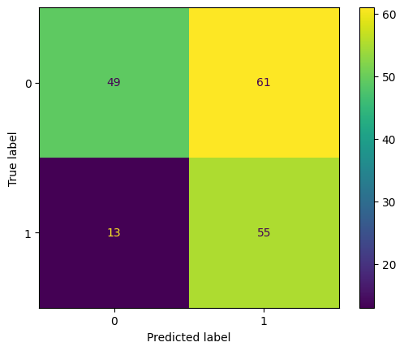

```
CNN Accuracy@k: {'Accuracy@10%': np.float64(52.94117647058824), 'Accuracy@20%': np.float64(54.285714285714285), 'Accuracy@30%': np.float64(50.943396226415096)}
```

```python
# Reshape input data for Conv1D: (n_samples, n_features) -> (n_samples, timesteps, features)
# Here, we treat each feature as a timestep, and the 'features' dimension is 1.
n_samples_train, n_features_train = x_train.shape
n_samples_test, n_features_test = x_test.shape

x_train_reshaped = x_train.reshape(n_samples_train, n_features_train, 1)
x_test_reshaped = x_test.reshape(n_samples_test, n_features_test, 1)

# Define the Conv1D model
model = models.Sequential([
    layers.Conv1D(filters=32, kernel_size=2, activation='relu', input_shape=(n_features_train, 1)),
    layers.MaxPooling1D(pool_size=1),
    layers.Flatten(),
    layers.Dense(32, activation='relu'),
    layers.Dense(1, activation='sigmoid') # Sigmoid for binary classification
])

# Compile the model
model.compile(optimizer='adam', loss='binary_crossentropy', metrics=['accuracy'])

# Train the model
history = model.fit(x_train_reshaped, y_train, epochs=50, batch_size=32, verbose=0)

# Predict probabilities on test data
y_pred_proba = model.predict(x_test_reshaped)
# Convert probabilities to binary predictions using a threshold (e.g., 0.5)
y_pred = (y_pred_proba > 0.5).astype(int)

# Accuracy on test data
train_score_cnn = metrics.accuracy_score(y_test, y_pred)
print('Accuracy score : ', train_score_cnn)
print("Accuracy percent of CNN : ", round(train_score_cnn*100, 1), "%")

# Evaluate the model on the reshaped test data
loss, accuracy = model.evaluate(x_test_reshaped, y_test, verbose=0)
print(f"Model Loss (on test data): {loss:.4f}")
print(f"Model Accuracy (on test data): {accuracy:.4f}")

# Classification report and confusion matrix
print("\nCNN Classification Report:\n", metrics.classification_report(y_test, y_pred))
cm = metrics.confusion_matrix(y_test, y_pred)
print("\nConfusion Matrix:\n", cm)

# TN, FP, FN, TP
TN, FP, FN, TP = cm.ravel()
print("TN={0}, FP={1}, FN={2}, TP={3}".format(TN, FP, FN, TP))

# Confusion matrix plot
disp = metrics.ConfusionMatrixDisplay(confusion_matrix=cm)
disp.plot()
plt.show()

# Calculate Accuracy@k
cnn_accuracy_at_k = calculate_accuracy_at_k(y_test, y_pred_proba.flatten(), [0.10, 0.20, 0.30])
print("\nCNN Accuracy@k:", cnn_accuracy_at_k)
```

### **18. Recurrent Neural Networks (RNN/LSTM)**

Best for sequential data.

```
c:\Users\GREAT EZEKIEL\AppData\Local\Programs\Python\Python313\Lib\site-packages\keras\src\layers\rnn\rnn.py:199: UserWarning: Do not pass an `input_shape`/`input_dim` argument to a layer. When using Sequential models, prefer using an `Input(shape)` object as the first layer in the model instead.
  super().__init__(**kwargs)
```

```
6/6 ━━━━━━━━━━━━━━━━━━━━ 1s 65ms/step
Accuracy score :  0.6404494382022472
Accuracy percent of RNN (LSTM) :  64.0 %
Model Loss (on test data): 0.6378
Model Accuracy (on test data): 0.6404

RNN (LSTM) Classification Report:
               precision    recall  f1-score   support

           0       0.77      0.59      0.67       110
           1       0.52      0.72      0.60        68

    accuracy                           0.64       178
   macro avg       0.65      0.66      0.64       178
weighted avg       0.68      0.64      0.65       178


Confusion Matrix:
 [[65 45]
 [19 49]]
TN=65, FP=45, FN=19, TP=49
```

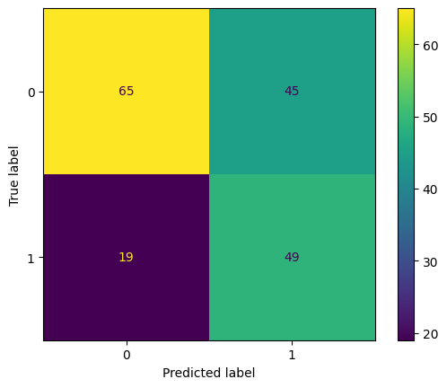

```
RNN (LSTM) Accuracy@k: {'Accuracy@10%': np.float64(64.70588235294117), 'Accuracy@20%': np.float64(60.0), 'Accuracy@30%': np.float64(52.83018867924528)}
```

```python
# Reshape input data for LSTM: (n_samples, n_features) -> (n_samples, timesteps, features)
# Here, we treat each feature as a timestep, and the 'features' dimension is 1.
n_samples_train, n_features_train = x_train.shape
n_samples_test, n_features_test = x_test.shape

x_train_reshaped = x_train.reshape(n_samples_train, n_features_train, 1)
x_test_reshaped = x_test.reshape(n_samples_test, n_features_test, 1)

# Define the LSTM model
model = models.Sequential([
    layers.LSTM(64, input_shape=(n_features_train, 1), activation='relu'),
    layers.Dense(32, activation='relu'),
    layers.Dense(1, activation='sigmoid') # Sigmoid for binary classification
])

# Compile the model
model.compile(optimizer='adam', loss='binary_crossentropy', metrics=['accuracy'])

# Train the model
history = model.fit(x_train_reshaped, y_train, epochs=50, batch_size=32, verbose=0)

# Predict probabilities on test data
y_pred_proba = model.predict(x_test_reshaped)
# Convert probabilities to binary predictions using a threshold (e.g., 0.5)
y_pred = (y_pred_proba > 0.5).astype(int)

# Accuracy on test data
train_score_lstm = metrics.accuracy_score(y_test, y_pred)
print('Accuracy score : ', train_score_lstm)
print("Accuracy percent of RNN (LSTM) : ", round(train_score_lstm*100, 1), "%")

# Evaluate the model on the reshaped test data
loss, accuracy = model.evaluate(x_test_reshaped, y_test, verbose=0)
print(f"Model Loss (on test data): {loss:.4f}")
print(f"Model Accuracy (on test data): {accuracy:.4f}")

# Classification report and confusion matrix
print("\nRNN (LSTM) Classification Report:\n", metrics.classification_report(y_test, y_pred))
cm = metrics.confusion_matrix(y_test, y_pred)
print("\nConfusion Matrix:\n", cm)

# TN, FP, FN, TP
TN, FP, FN, TP = cm.ravel()
print("TN={0}, FP={1}, FN={2}, TP={3}".format(TN, FP, FN, TP))

# Confusion matrix plot
disp = metrics.ConfusionMatrixDisplay(confusion_matrix=cm)
disp.plot()
plt.show()

# Calculate Accuracy@k
lstm_accuracy_at_k = calculate_accuracy_at_k(y_test, y_pred_proba.flatten(), [0.10, 0.20, 0.30])
print("\nRNN (LSTM) Accuracy@k:", lstm_accuracy_at_k)
```